# Risk Factor Analysis

## Outcome Variable

**Outcome Variable:** pers_wasted624

## Predictor Variables

**Intervention Variable:** ever_sunderweight06

**Adjustment Set:**

unadjusted

## Stratifying Variables

The analysis was stratified on these variable(s):

- studyid
- country

## Data Summary

| studyid | country | ever_sunderweight06 | pers_wasted624 | n_cell | n |
| --- | --- | --- | --- | --- | --- |
| ki0047075b-MAL-ED | BANGLADESH | 0 | 0 | 213 | 240 |
| ki0047075b-MAL-ED | BANGLADESH | 0 | 1 | 15 | 240 |
| ki0047075b-MAL-ED | BANGLADESH | 1 | 0 | 9 | 240 |
| ki0047075b-MAL-ED | BANGLADESH | 1 | 1 | 3 | 240 |
| ki0047075b-MAL-ED | BRAZIL | 0 | 0 | 200 | 202 |
| ki0047075b-MAL-ED | BRAZIL | 0 | 1 | 2 | 202 |
| ki0047075b-MAL-ED | BRAZIL | 1 | 0 | 0 | 202 |
| ki0047075b-MAL-ED | BRAZIL | 1 | 1 | 0 | 202 |
| ki0047075b-MAL-ED | INDIA | 0 | 0 | 188 | 234 |
| ki0047075b-MAL-ED | INDIA | 0 | 1 | 17 | 234 |
| ki0047075b-MAL-ED | INDIA | 1 | 0 | 18 | 234 |
| ki0047075b-MAL-ED | INDIA | 1 | 1 | 11 | 234 |
| ki0047075b-MAL-ED | NEPAL | 0 | 0 | 224 | 234 |
| ki0047075b-MAL-ED | NEPAL | 0 | 1 | 1 | 234 |
| ki0047075b-MAL-ED | NEPAL | 1 | 0 | 8 | 234 |
| ki0047075b-MAL-ED | NEPAL | 1 | 1 | 1 | 234 |
| ki0047075b-MAL-ED | PERU | 0 | 0 | 255 | 264 |
| ki0047075b-MAL-ED | PERU | 0 | 1 | 2 | 264 |
| ki0047075b-MAL-ED | PERU | 1 | 0 | 7 | 264 |
| ki0047075b-MAL-ED | PERU | 1 | 1 | 0 | 264 |
| ki0047075b-MAL-ED | SOUTH AFRICA | 0 | 0 | 249 | 258 |
| ki0047075b-MAL-ED | SOUTH AFRICA | 0 | 1 | 2 | 258 |
| ki0047075b-MAL-ED | SOUTH AFRICA | 1 | 0 | 7 | 258 |
| ki0047075b-MAL-ED | SOUTH AFRICA | 1 | 1 | 0 | 258 |
| ki0047075b-MAL-ED | TANZANIA, UNITED REPUBLIC OF | 0 | 0 | 237 | 244 |
| ki0047075b-MAL-ED | TANZANIA, UNITED REPUBLIC OF | 0 | 1 | 0 | 244 |
| ki0047075b-MAL-ED | TANZANIA, UNITED REPUBLIC OF | 1 | 0 | 7 | 244 |
| ki0047075b-MAL-ED | TANZANIA, UNITED REPUBLIC OF | 1 | 1 | 0 | 244 |
| ki1000108-CMC-V-BCS-2002 | INDIA | 0 | 0 | 290 | 368 |
| ki1000108-CMC-V-BCS-2002 | INDIA | 0 | 1 | 14 | 368 |

[output cut: 102 more lines]

The following strata were considered:

- studyid: ki0047075b-MAL-ED, country: BANGLADESH
- studyid: ki0047075b-MAL-ED, country: BRAZIL
- studyid: ki0047075b-MAL-ED, country: INDIA
- studyid: ki0047075b-MAL-ED, country: NEPAL
- studyid: ki0047075b-MAL-ED, country: PERU
- studyid: ki0047075b-MAL-ED, country: SOUTH AFRICA
- studyid: ki0047075b-MAL-ED, country: TANZANIA, UNITED REPUBLIC OF
- studyid: ki1000108-CMC-V-BCS-2002, country: INDIA
- studyid: ki1000108-IRC, country: INDIA
- studyid: ki1000109-EE, country: PAKISTAN
- studyid: ki1000109-ResPak, country: PAKISTAN
- studyid: ki1000304b-SAS-CompFeed, country: INDIA
- studyid: ki1000304b-SAS-FoodSuppl, country: INDIA
- studyid: ki1017093-NIH-Birth, country: BANGLADESH
- studyid: ki1017093b-PROVIDE, country: BANGLADESH
- studyid: ki1017093c-NIH-Crypto, country: BANGLADESH
- studyid: ki1066203-TanzaniaChild2, country: TANZANIA, UNITED REPUBLIC OF
- studyid: ki1101329-Keneba, country: GAMBIA
- studyid: ki1112895-Guatemala BSC, country: GUATEMALA
- studyid: ki1113344-GMS-Nepal, country: NEPAL
- studyid: ki1114097-CMIN, country: BANGLADESH
- studyid: ki1114097-CMIN, country: BRAZIL
- studyid: ki1114097-CMIN, country: GUINEA-BISSAU
- studyid: ki1114097-CMIN, country: PERU
- studyid: ki1114097-CONTENT, country: PERU
- studyid: ki1119695-PROBIT, country: BELARUS
- studyid: ki1126311-ZVITAMBO, country: ZIMBABWE
- studyid: ki1135781-COHORTS, country: GUATEMALA
- studyid: ki1135781-COHORTS, country: INDIA
- studyid: ki1135781-COHORTS, country: PHILIPPINES
- studyid: ki1148112-LCNI-5, country: MALAWI
- studyid: kiGH5241-JiVitA-3, country: BANGLADESH
- studyid: kiGH5241-JiVitA-4, country: BANGLADESH

### Dropped Strata

Some strata were dropped due to rare outcomes:

- studyid: ki0047075b-MAL-ED, country: BANGLADESH
- studyid: ki0047075b-MAL-ED, country: BRAZIL
- studyid: ki0047075b-MAL-ED, country: NEPAL
- studyid: ki0047075b-MAL-ED, country: PERU
- studyid: ki0047075b-MAL-ED, country: SOUTH AFRICA
- studyid: ki0047075b-MAL-ED, country: TANZANIA, UNITED REPUBLIC OF
- studyid: ki1112895-Guatemala BSC, country: GUATEMALA
- studyid: ki1114097-CMIN, country: BRAZIL
- studyid: ki1114097-CMIN, country: GUINEA-BISSAU
- studyid: ki1114097-CMIN, country: PERU
- studyid: ki1114097-CONTENT, country: PERU
- studyid: ki1119695-PROBIT, country: BELARUS
- studyid: ki1148112-LCNI-5, country: MALAWI

## Methods Detail

We’re interested in the causal parameters $E[Y_a]$ for all values of $a \in \mathcal{A}$. These parameters represent the mean outcome if, possibly contrary to fact, we intervened to set all units to have $A=a$. Under the randomization and positivity assumptions, these are identified by the statistical parameters $\psi_a=E_W[E_{Y|A,W}(Y|A=a,W)]$. In addition, we’re interested in the mean of $Y$, $E[Y]$ under no intervention (the observed mean). We will estimate these parameters by using SuperLearner to fit the relevant likelihood factors – $E_{Y|A,W}(Y|A=a,W)$ and $p(A=a|W)$, and then updating our likelihood fit using a joint TMLE.

For unadjusted analyses ($W=\{\}$), initial likelihoods were estimated using Lrnr_glm to estimate the simple $E(Y|A)$ and Lrnr_mean to estimate $p(A)$. For adjusted analyses, a small library containing Lrnr_glmnet, Lrnr_xgboost, and Lrnr_mean was used.

Having estimated these parameters, we will then use the delta method to estimate relative risks and attributable risks relative to a prespecified baseline level of $A$.

# Results Detail

## Results Plots

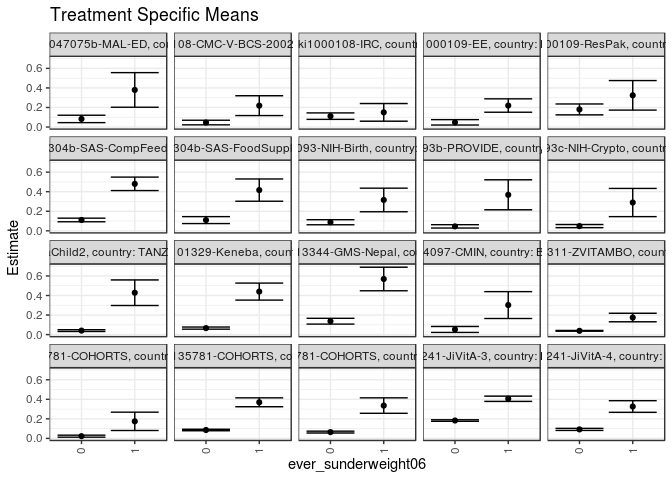

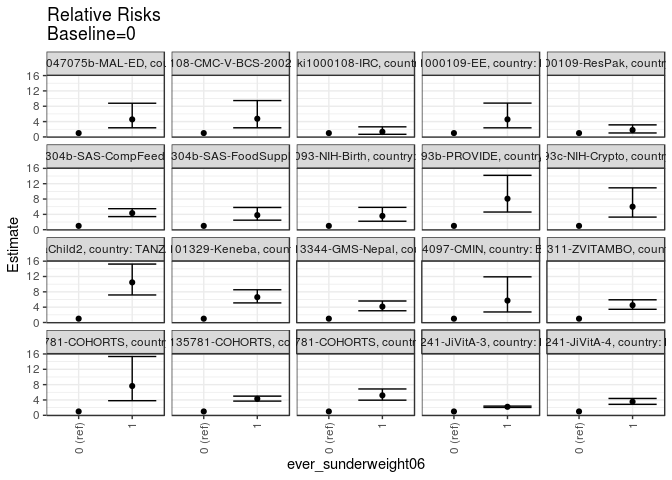

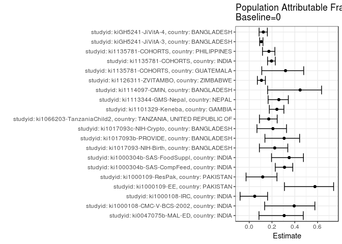

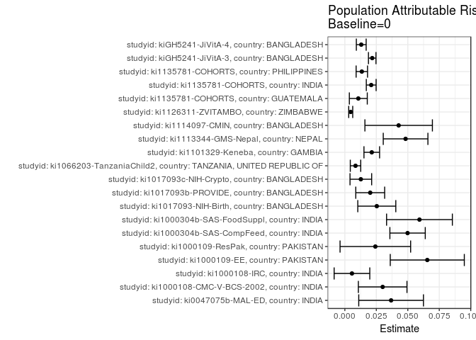

## Results Table

### Parameter: TSM

| studyid | country | intervention_level | baseline_level | estimate | ci_lower | ci_upper |
| --- | --- | --- | --- | --- | --- | --- |
| ki0047075b-MAL-ED | INDIA | 0 | NA | 0.0829268 | 0.0450956 | 0.1207581 |
| ki0047075b-MAL-ED | INDIA | 1 | NA | 0.3793103 | 0.2023346 | 0.5562861 |
| ki1000108-CMC-V-BCS-2002 | INDIA | 0 | NA | 0.0460526 | 0.0224592 | 0.0696461 |
| ki1000108-CMC-V-BCS-2002 | INDIA | 1 | NA | 0.2187500 | 0.1173313 | 0.3201687 |
| ki1000108-IRC | INDIA | 0 | NA | 0.1114286 | 0.0784229 | 0.1444343 |
| ki1000108-IRC | INDIA | 1 | NA | 0.1500000 | 0.0595397 | 0.2404603 |
| ki1000109-EE | PAKISTAN | 0 | NA | 0.0480349 | 0.0203013 | 0.0757686 |
| ki1000109-EE | PAKISTAN | 1 | NA | 0.2198582 | 0.1514064 | 0.2883099 |
| ki1000109-ResPak | PAKISTAN | 0 | NA | 0.1803279 | 0.1244984 | 0.2361573 |
| ki1000109-ResPak | PAKISTAN | 1 | NA | 0.3243243 | 0.1731440 | 0.4755047 |
| ki1000304b-SAS-CompFeed | INDIA | 0 | NA | 0.1110155 | 0.0924345 | 0.1295965 |
| ki1000304b-SAS-CompFeed | INDIA | 1 | NA | 0.4806630 | 0.4118888 | 0.5494371 |
| ki1000304b-SAS-FoodSuppl | INDIA | 0 | NA | 0.1096346 | 0.0742914 | 0.1449777 |
| ki1000304b-SAS-FoodSuppl | INDIA | 1 | NA | 0.4166667 | 0.3026371 | 0.5306963 |
| ki1017093-NIH-Birth | BANGLADESH | 0 | NA | 0.0879121 | 0.0618680 | 0.1139562 |
| ki1017093-NIH-Birth | BANGLADESH | 1 | NA | 0.3157895 | 0.1950001 | 0.4365789 |
| ki1017093b-PROVIDE | BANGLADESH | 0 | NA | 0.0455342 | 0.0284208 | 0.0626475 |
| ki1017093b-PROVIDE | BANGLADESH | 1 | NA | 0.3684211 | 0.2149243 | 0.5219178 |
| ki1017093c-NIH-Crypto | BANGLADESH | 0 | NA | 0.0482456 | 0.0321757 | 0.0643155 |
| ki1017093c-NIH-Crypto | BANGLADESH | 1 | NA | 0.2894737 | 0.1451785 | 0.4337689 |
| ki1066203-TanzaniaChild2 | TANZANIA, UNITED REPUBLIC OF | 0 | NA | 0.0409574 | 0.0319673 | 0.0499476 |
| ki1066203-TanzaniaChild2 | TANZANIA, UNITED REPUBLIC OF | 1 | NA | 0.4285714 | 0.2977181 | 0.5594248 |
| ki1101329-Keneba | GAMBIA | 0 | NA | 0.0665695 | 0.0557973 | 0.0773417 |
| ki1101329-Keneba | GAMBIA | 1 | NA | 0.4400000 | 0.3529612 | 0.5270388 |
| ki1113344-GMS-Nepal | NEPAL | 0 | NA | 0.1373308 | 0.1076358 | 0.1670257 |
| ki1113344-GMS-Nepal | NEPAL | 1 | NA | 0.5692308 | 0.4487462 | 0.6897153 |
| ki1114097-CMIN | BANGLADESH | 0 | NA | 0.0528846 | 0.0224092 | 0.0833600 |
| ki1114097-CMIN | BANGLADESH | 1 | NA | 0.3023256 | 0.1647807 | 0.4398705 |
| ki1126311-ZVITAMBO | ZIMBABWE | 0 | NA | 0.0386814 | 0.0345128 | 0.0428501 |
| ki1126311-ZVITAMBO | ZIMBABWE | 1 | NA | 0.1746575 | 0.1311071 | 0.2182080 |
| ki1135781-COHORTS | GUATEMALA | 0 | NA | 0.0228640 | 0.0126958 | 0.0330322 |
| ki1135781-COHORTS | GUATEMALA | 1 | NA | 0.1746032 | 0.0808085 | 0.2683979 |
| ki1135781-COHORTS | INDIA | 0 | NA | 0.0859878 | 0.0785313 | 0.0934444 |
| ki1135781-COHORTS | INDIA | 1 | NA | 0.3695150 | 0.3240482 | 0.4149818 |
| ki1135781-COHORTS | PHILIPPINES | 0 | NA | 0.0645531 | 0.0551383 | 0.0739679 |
| ki1135781-COHORTS | PHILIPPINES | 1 | NA | 0.3357664 | 0.2566720 | 0.4148608 |
| kiGH5241-JiVitA-3 | BANGLADESH | 0 | NA | 0.1830403 | 0.1753094 | 0.1907711 |
| kiGH5241-JiVitA-3 | BANGLADESH | 1 | NA | 0.4054834 | 0.3785213 | 0.4324455 |
| kiGH5241-JiVitA-4 | BANGLADESH | 0 | NA | 0.0920997 | 0.0815507 | 0.1026487 |
| kiGH5241-JiVitA-4 | BANGLADESH | 1 | NA | 0.3261649 | 0.2666376 | 0.3856922 |

### Parameter: E(Y)

| studyid | country | intervention_level | baseline_level | estimate | ci_lower | ci_upper |
| --- | --- | --- | --- | --- | --- | --- |
| ki0047075b-MAL-ED | INDIA | NA | NA | 0.1196581 | 0.0779840 | 0.1613323 |
| ki1000108-CMC-V-BCS-2002 | INDIA | NA | NA | 0.0760870 | 0.0489610 | 0.1032130 |
| ki1000108-IRC | INDIA | NA | NA | 0.1170732 | 0.0859146 | 0.1482317 |
| ki1000109-EE | PAKISTAN | NA | NA | 0.1135135 | 0.0811471 | 0.1458799 |
| ki1000109-ResPak | PAKISTAN | NA | NA | 0.2045455 | 0.1511224 | 0.2579685 |
| ki1000304b-SAS-CompFeed | INDIA | NA | NA | 0.1608340 | 0.1401010 | 0.1815669 |
| ki1000304b-SAS-FoodSuppl | INDIA | NA | NA | 0.1689008 | 0.1308276 | 0.2069740 |
| ki1017093-NIH-Birth | BANGLADESH | NA | NA | 0.1132813 | 0.0858017 | 0.1407608 |
| ki1017093b-PROVIDE | BANGLADESH | NA | NA | 0.0656814 | 0.0459906 | 0.0853723 |
| ki1017093c-NIH-Crypto | BANGLADESH | NA | NA | 0.0609418 | 0.0434802 | 0.0784034 |
| ki1066203-TanzaniaChild2 | TANZANIA, UNITED REPUBLIC OF | NA | NA | 0.0494277 | 0.0397346 | 0.0591208 |
| ki1101329-Keneba | GAMBIA | NA | NA | 0.0879524 | 0.0760686 | 0.0998361 |
| ki1113344-GMS-Nepal | NEPAL | NA | NA | 0.1855670 | 0.1539560 | 0.2171780 |
| ki1114097-CMIN | BANGLADESH | NA | NA | 0.0956175 | 0.0591654 | 0.1320697 |
| ki1126311-ZVITAMBO | ZIMBABWE | NA | NA | 0.0433455 | 0.0390195 | 0.0476714 |
| ki1135781-COHORTS | GUATEMALA | NA | NA | 0.0335570 | 0.0217456 | 0.0453685 |
| ki1135781-COHORTS | INDIA | NA | NA | 0.1069236 | 0.0990137 | 0.1148335 |
| ki1135781-COHORTS | PHILIPPINES | NA | NA | 0.0780399 | 0.0680219 | 0.0880579 |
| kiGH5241-JiVitA-3 | BANGLADESH | NA | NA | 0.2047810 | 0.1972350 | 0.2123271 |
| kiGH5241-JiVitA-4 | BANGLADESH | NA | NA | 0.1051267 | 0.0943582 | 0.1158951 |

### Parameter: RR

| studyid | country | intervention_level | baseline_level | estimate | ci_lower | ci_upper |
| --- | --- | --- | --- | --- | --- | --- |
| ki0047075b-MAL-ED | INDIA | 0 | 0 | 1.000000 | 1.0000000 | 1.000000 |
| ki0047075b-MAL-ED | INDIA | 1 | 0 | 4.574037 | 2.3817990 | 8.784037 |
| ki1000108-CMC-V-BCS-2002 | INDIA | 0 | 0 | 1.000000 | 1.0000000 | 1.000000 |
| ki1000108-CMC-V-BCS-2002 | INDIA | 1 | 0 | 4.750000 | 2.3802135 | 9.479191 |
| ki1000108-IRC | INDIA | 0 | 0 | 1.000000 | 1.0000000 | 1.000000 |
| ki1000108-IRC | INDIA | 1 | 0 | 1.346154 | 0.6875415 | 2.635666 |
| ki1000109-EE | PAKISTAN | 0 | 0 | 1.000000 | 1.0000000 | 1.000000 |
| ki1000109-EE | PAKISTAN | 1 | 0 | 4.577047 | 2.3752265 | 8.819942 |
| ki1000109-ResPak | PAKISTAN | 0 | 0 | 1.000000 | 1.0000000 | 1.000000 |
| ki1000109-ResPak | PAKISTAN | 1 | 0 | 1.798526 | 1.0277583 | 3.147331 |
| ki1000304b-SAS-CompFeed | INDIA | 0 | 0 | 1.000000 | 1.0000000 | 1.000000 |
| ki1000304b-SAS-CompFeed | INDIA | 1 | 0 | 4.329693 | 3.4232931 | 5.476084 |
| ki1000304b-SAS-FoodSuppl | INDIA | 0 | 0 | 1.000000 | 1.0000000 | 1.000000 |
| ki1000304b-SAS-FoodSuppl | INDIA | 1 | 0 | 3.800505 | 2.4899506 | 5.800853 |
| ki1017093-NIH-Birth | BANGLADESH | 0 | 0 | 1.000000 | 1.0000000 | 1.000000 |
| ki1017093-NIH-Birth | BANGLADESH | 1 | 0 | 3.592105 | 2.2142846 | 5.827264 |
| ki1017093b-PROVIDE | BANGLADESH | 0 | 0 | 1.000000 | 1.0000000 | 1.000000 |
| ki1017093b-PROVIDE | BANGLADESH | 1 | 0 | 8.091093 | 4.6166103 | 14.180488 |
| ki1017093c-NIH-Crypto | BANGLADESH | 0 | 0 | 1.000000 | 1.0000000 | 1.000000 |
| ki1017093c-NIH-Crypto | BANGLADESH | 1 | 0 | 6.000000 | 3.2944569 | 10.927446 |
| ki1066203-TanzaniaChild2 | TANZANIA, UNITED REPUBLIC OF | 0 | 0 | 1.000000 | 1.0000000 | 1.000000 |
| ki1066203-TanzaniaChild2 | TANZANIA, UNITED REPUBLIC OF | 1 | 0 | 10.463822 | 7.1842234 | 15.240557 |
| ki1101329-Keneba | GAMBIA | 0 | 0 | 1.000000 | 1.0000000 | 1.000000 |
| ki1101329-Keneba | GAMBIA | 1 | 0 | 6.609635 | 5.1189948 | 8.534346 |
| ki1113344-GMS-Nepal | NEPAL | 0 | 0 | 1.000000 | 1.0000000 | 1.000000 |
| ki1113344-GMS-Nepal | NEPAL | 1 | 0 | 4.144962 | 3.0627449 | 5.609579 |
| ki1114097-CMIN | BANGLADESH | 0 | 0 | 1.000000 | 1.0000000 | 1.000000 |
| ki1114097-CMIN | BANGLADESH | 1 | 0 | 5.716702 | 2.7433582 | 11.912655 |
| ki1126311-ZVITAMBO | ZIMBABWE | 0 | 0 | 1.000000 | 1.0000000 | 1.000000 |
| ki1126311-ZVITAMBO | ZIMBABWE | 1 | 0 | 4.515282 | 3.4412239 | 5.924569 |
| ki1135781-COHORTS | GUATEMALA | 0 | 0 | 1.000000 | 1.0000000 | 1.000000 |
| ki1135781-COHORTS | GUATEMALA | 1 | 0 | 7.636591 | 3.8021337 | 15.338106 |
| ki1135781-COHORTS | INDIA | 0 | 0 | 1.000000 | 1.0000000 | 1.000000 |
| ki1135781-COHORTS | INDIA | 1 | 0 | 4.297293 | 3.6967491 | 4.995397 |
| ki1135781-COHORTS | PHILIPPINES | 0 | 0 | 1.000000 | 1.0000000 | 1.000000 |
| ki1135781-COHORTS | PHILIPPINES | 1 | 0 | 5.201399 | 3.9427151 | 6.861910 |
| kiGH5241-JiVitA-3 | BANGLADESH | 0 | 0 | 1.000000 | 1.0000000 | 1.000000 |
| kiGH5241-JiVitA-3 | BANGLADESH | 1 | 0 | 2.215269 | 2.0443576 | 2.400469 |
| kiGH5241-JiVitA-4 | BANGLADESH | 0 | 0 | 1.000000 | 1.0000000 | 1.000000 |
| kiGH5241-JiVitA-4 | BANGLADESH | 1 | 0 | 3.541432 | 2.8592589 | 4.386362 |

### Parameter: PAR

| studyid | country | intervention_level | baseline_level | estimate | ci_lower | ci_upper |
| --- | --- | --- | --- | --- | --- | --- |
| ki0047075b-MAL-ED | INDIA | 0 | NA | 0.0367313 | 0.0110355 | 0.0624271 |
| ki1000108-CMC-V-BCS-2002 | INDIA | 0 | NA | 0.0300343 | 0.0107267 | 0.0493420 |
| ki1000108-IRC | INDIA | 0 | NA | 0.0056446 | -0.0085089 | 0.0197981 |
| ki1000109-EE | PAKISTAN | 0 | NA | 0.0654786 | 0.0360736 | 0.0948835 |
| ki1000109-ResPak | PAKISTAN | 0 | NA | 0.0242176 | -0.0038095 | 0.0522446 |
| ki1000304b-SAS-CompFeed | INDIA | 0 | NA | 0.0498185 | 0.0357676 | 0.0638694 |
| ki1000304b-SAS-FoodSuppl | INDIA | 0 | NA | 0.0592663 | 0.0331384 | 0.0853941 |
| ki1017093-NIH-Birth | BANGLADESH | 0 | NA | 0.0253692 | 0.0102742 | 0.0404641 |
| ki1017093b-PROVIDE | BANGLADESH | 0 | NA | 0.0201473 | 0.0086838 | 0.0316108 |
| ki1017093c-NIH-Crypto | BANGLADESH | 0 | NA | 0.0126962 | 0.0041026 | 0.0212898 |
| ki1066203-TanzaniaChild2 | TANZANIA, UNITED REPUBLIC OF | 0 | NA | 0.0084702 | 0.0043261 | 0.0126144 |
| ki1101329-Keneba | GAMBIA | 0 | NA | 0.0213829 | 0.0151802 | 0.0275855 |
| ki1113344-GMS-Nepal | NEPAL | 0 | NA | 0.0482363 | 0.0305041 | 0.0659684 |
| ki1114097-CMIN | BANGLADESH | 0 | NA | 0.0427329 | 0.0159332 | 0.0695326 |
| ki1126311-ZVITAMBO | ZIMBABWE | 0 | NA | 0.0046640 | 0.0030740 | 0.0062541 |
| ki1135781-COHORTS | GUATEMALA | 0 | NA | 0.0106930 | 0.0035734 | 0.0178127 |
| ki1135781-COHORTS | INDIA | 0 | NA | 0.0209358 | 0.0170400 | 0.0248315 |
| ki1135781-COHORTS | PHILIPPINES | 0 | NA | 0.0134868 | 0.0089550 | 0.0180187 |
| kiGH5241-JiVitA-3 | BANGLADESH | 0 | NA | 0.0217408 | 0.0187563 | 0.0247253 |
| kiGH5241-JiVitA-4 | BANGLADESH | 0 | NA | 0.0130270 | 0.0091279 | 0.0169260 |

### Parameter: PAF

| studyid | country | intervention_level | baseline_level | estimate | ci_lower | ci_upper |
| --- | --- | --- | --- | --- | --- | --- |
| ki0047075b-MAL-ED | INDIA | 0 | NA | 0.3069686 | 0.0858243 | 0.4746169 |
| ki1000108-CMC-V-BCS-2002 | INDIA | 0 | NA | 0.3947368 | 0.1354783 | 0.5762472 |
| ki1000108-IRC | INDIA | 0 | NA | 0.0482143 | -0.0801150 | 0.1612966 |
| ki1000109-EE | PAKISTAN | 0 | NA | 0.5768351 | 0.3093044 | 0.7407418 |
| ki1000109-ResPak | PAKISTAN | 0 | NA | 0.1183971 | -0.0276046 | 0.2436549 |
| ki1000304b-SAS-CompFeed | INDIA | 0 | NA | 0.3097509 | 0.2288709 | 0.3821478 |
| ki1000304b-SAS-FoodSuppl | INDIA | 0 | NA | 0.3508938 | 0.1958744 | 0.4760286 |
| ki1017093-NIH-Birth | BANGLADESH | 0 | NA | 0.2239485 | 0.0894263 | 0.3385972 |
| ki1017093b-PROVIDE | BANGLADESH | 0 | NA | 0.3067426 | 0.1379207 | 0.4425039 |
| ki1017093c-NIH-Crypto | BANGLADESH | 0 | NA | 0.2083333 | 0.0680155 | 0.3275252 |
| ki1066203-TanzaniaChild2 | TANZANIA, UNITED REPUBLIC OF | 0 | NA | 0.1713662 | 0.0899357 | 0.2455105 |
| ki1101329-Keneba | GAMBIA | 0 | NA | 0.2431188 | 0.1767111 | 0.3041700 |
| ki1113344-GMS-Nepal | NEPAL | 0 | NA | 0.2599398 | 0.1659352 | 0.3433495 |
| ki1114097-CMIN | BANGLADESH | 0 | NA | 0.4469151 | 0.1616344 | 0.6351199 |
| ki1126311-ZVITAMBO | ZIMBABWE | 0 | NA | 0.1076017 | 0.0716889 | 0.1421252 |
| ki1135781-COHORTS | GUATEMALA | 0 | NA | 0.3186522 | 0.1103660 | 0.4781733 |
| ki1135781-COHORTS | INDIA | 0 | NA | 0.1958011 | 0.1610404 | 0.2291215 |
| ki1135781-COHORTS | PHILIPPINES | 0 | NA | 0.1728197 | 0.1166930 | 0.2253799 |
| kiGH5241-JiVitA-3 | BANGLADESH | 0 | NA | 0.1061661 | 0.0914759 | 0.1206187 |
| kiGH5241-JiVitA-4 | BANGLADESH | 0 | NA | 0.1239169 | 0.0869097 | 0.1594241 |